# homework5

##### 1.Proof:

Maximum Likelihood Estimation:  
Derivation Sketch:Let $\theta_k = P(Y = c_k)$ with $\sum_{k=1}^K \theta_k = 1$.  
Likelihood function for labels: $L = \prod_{k=1}^K \theta_k^{N_k}$ where $N_k = \sum_{i=1}^N I(y_i = c_k)$.  
Log-likelihood: $\ln L = \sum_{k=1}^K N_k \ln \theta_k$.Maximizing with Lagrange multiplier under $\sum \theta_k = 1$ gives $\theta_k = \frac{N_k}{N}$.  
Conditional Probability:  
Derivation Sketch:Let $\theta_{kl}^{(j)} = P(X^{(j)} = a_{jl} | Y = c_k)$ with $\sum_{l=1}^{S_j} \theta_{kl}^{(j)} = 1$.  
Likelihood for feature j (given $Y = c_k$): $L = \prod_{l=1}^{S_j} (\theta_{kl}^{(j)})^{N_{kl}^{(j)}}$ where $N_{kl}^{(j)} = \sum I(X_i^{(j)} = a_{jl}, y_i = c_k)$.  
Log-likelihood: $\ln L = \sum_{l=1}^{S_j} N_{kl}^{(j)} \ln \theta_{kl}^{(j)}$.Maximizing with constraint $\sum \theta_{kl}^{(j)} = 1$ gives $\theta_{kl}^{(j)} = \frac{N_{kl}^{(j)}}{N_k}$ (where $N_k = \sum I(y_i = c_k)$).

##### 2.Solution:

Maximum Likelihood Estimation:  
$P(Y=1)=\frac{10}{15}, P(Y=-1)=\frac{5}{15}$  
$P(X^{(1)}=2|Y=1)=\frac{2}{10}, P(X^{(1)}=2|Y=-1)=\frac{3}{5}, P(X^{(2)}=M|Y=1)=\frac{4}{10}, P(X^{(2)}=M|Y=-1)=\frac{2}{5}$  
$P(Y=1)P(X^{(1)}=2|Y=1)P(X^{(2)}=M|Y=1)=\frac{4}{75}$  
$P(Y=-1)P(X^{(1)}=2|Y=-1)P(X^{(2)}=M|Y=-1)=\frac{6}{75}$  
Thus, $Y=-1$  
Beyes Estimation:  
When $\lambda = 1$, we have $P(Y=1)=\frac{11}{17}, P(Y=-1)=\frac{6}{17}$  
$P(X^{(1)}=2|Y=1)=\frac{3}{13},P(X^{(1)}=2|Y=-1)=\frac{4}{8},P(X^{(2)}=M|Y=1)=\frac{5}{12}, P(X^{(2)}=M|Y=-1)=\frac{3}{7}$  
$P(Y=1)P(X^{(1)}=2|Y=1)P(X^{(2)}=M|Y=1)=\frac{165}{2652}$  
$P(Y=-1)P(X^{(1)}=2|Y=-1)P(X^{(2)}=M|Y=-1)=\frac{18}{238}$  
Thus, $Y=-1$

[output not shown]

[output cut: 49 more lines]

[output not shown]

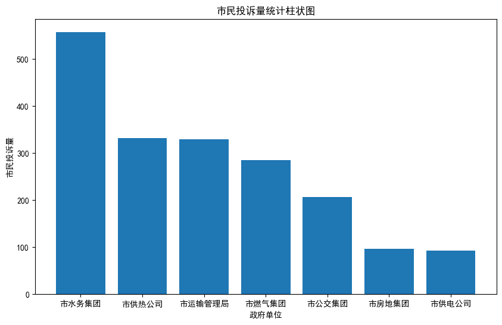

```python
'''(3.1)'''
import numpy as np
import pandas as pd
import matplotlib.pyplot as plt

np.random.seed(3047)
plt.rcParams["font.family"] = ["SimHei", "WenQuanYi Micro Hei", "Heiti TC"]
train_data = pd.read_csv("train_set.csv")
test_data = pd.read_csv("test_set.csv")

group_count = train_data.groupby(by="单位名称").size()
result_df = group_count.reset_index()
result_df.columns = ["政府单位", "市民投诉量"]
result_df = result_df.sort_values(by="市民投诉量", ascending=False)

plt.figure(figsize=(10, 6))
x = result_df["政府单位"]
y = result_df["市民投诉量"]
plt.bar(x, y)
plt.title("市民投诉量统计柱状图")
plt.xlabel("政府单位")
plt.ylabel("市民投诉量")
plt.show()
```

市民对于市水务集团的投诉量最多，超过500次，市房地集团和市供电公司的投诉量最少。

[output not shown]

[output cut: 47 more lines]

[output not shown]

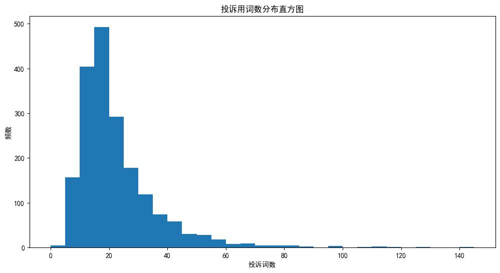

```python
'''(3.2)'''
word_number = train_data.sum(axis=1, numeric_only=True).to_frame(name="投诉词数")
word_columns = train_data.columns[1:]
train_data['每条投诉用词数'] = train_data[word_columns].sum(axis=1)


plt.figure(figsize=(12, 6))
bins = np.arange(0, train_data['每条投诉用词数'].max() + 5, 5)
n, bins, patches = plt.hist(x=train_data['每条投诉用词数'], bins=bins)

plt.title("投诉用词数分布直方图")
plt.xlabel("投诉词数")
plt.ylabel("频数")
plt.show()
```

[output not shown]

[output cut: 63 more lines]

[output not shown]

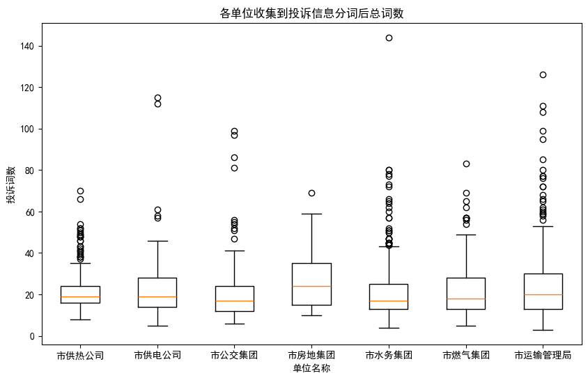

```python
'''(3.3)'''
word_number_sum = word_number.join(train_data["单位名称"])
groups = word_number_sum.groupby(by="单位名称")
data = [group["投诉词数"].values for name, group in groups]
labels = [name for name, group in groups]

plt.figure(figsize=(10, 6))
plt.boxplot(x=data, labels=labels)
plt.xlabel("单位名称")
plt.ylabel("投诉词数")
plt.title("各单位收集到投诉信息分词后总词数")
plt.show()
```

各个公司或集团的投诉次数集中在20词左右，市运输管理局、市供热公司和市水务集团偏离平均值的数据较多

[output not shown]

```
=== 朴素贝叶斯模型信息 ===
训练集样本数: 1900
测试集样本数: 100
特征数（词汇数）: 6235
类别数（单位数）: 7
```

[output not shown]

[output cut: 166 more lines]

[output not shown]

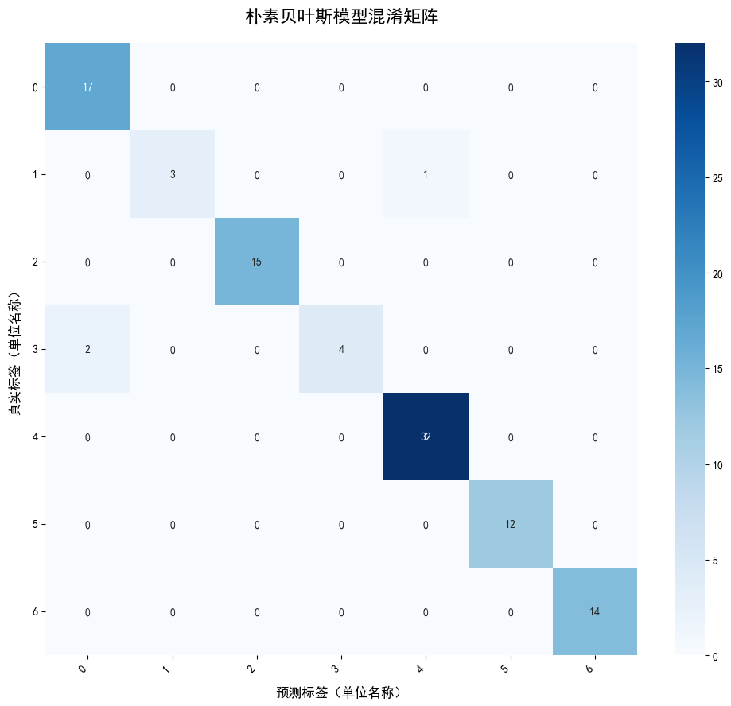

```python
'''(3.4)'''
from sklearn.naive_bayes import MultinomialNB
from sklearn.metrics import confusion_matrix, roc_curve, auc, classification_report
from sklearn.preprocessing import label_binarize

X_train = train_data[word_columns].values
y_train = train_data['单位名称'].values
X_test = test_data[word_columns].values
y_test = test_data['单位名称'].values

from sklearn.preprocessing import LabelEncoder
le = LabelEncoder()
y_train_encoded = le.fit_transform(y_train)
y_test_encoded = le.transform(y_test)

nb_model = MultinomialNB(alpha=1.0)
nb_model.fit(X_train, y_train_encoded)

y_pred_encoded = nb_model.predict(X_test)
y_pred_proba = nb_model.predict_proba(X_test)

print(f"\n=== 朴素贝叶斯模型信息 ===")
print(f"训练集样本数: {X_train.shape[0]}")
print(f"测试集样本数: {X_test.shape[0]}")
print(f"特征数（词汇数）: {X_train.shape[1]}")
print(f"类别数（单位数）: {len(le.classes_)}")

cm = confusion_matrix(y_test_encoded, y_pred_encoded)

import seaborn as sns
plt.figure(figsize=(12, 10))
sns.heatmap(
    cm,
    annot=True,
    fmt='d',
    cmap='Blues',

)
plt.title('朴素贝叶斯模型混淆矩阵', fontsize=16, fontweight='bold', pad=20)
plt.xlabel('预测标签（单位名称）', fontsize=12, labelpad=10)
plt.ylabel('真实标签（单位名称）', fontsize=12, labelpad=10)
plt.xticks(rotation=45, ha='right')
plt.yticks(rotation=0)
plt.show()
```